# Passby Noise Across Frequencies

# Overview

Goal is to assess the noise measurements from passby measurements in 2018, where four quiet pavement treatments were applied to test areas: 1/4 in chip seal, 3/8 in chip seal, Type II microsurfacing, and Type III microsurfacing.

There are eight sites, and four pavement treatments; each pavement treatment is replicated at two sites. Sound intensity was measured pre-treatment and post-treatment.

In the original assessment, overall the Type II microsurfacing was found to reduce overall sound intensity sound from OBSI measurements from 99.2 dB on average to 97.6. Other treatments did not on average reduce sound levels.

This analysis focuses on the observational passby data, where vehicle type varies, and assesses the effects of speed and pavement temperature in addition to experimental treatments.

Summary of passby data collected by year and treatment.

| Year | Treatment | N total | N autos | Mean speed | SD speed | Mean pavement temp | SD pavement temp |
| --- | --- | --- | --- | --- | --- | --- | --- |
| 2016 | Baseline - Chip Seal | 95 | 93 | 53.47 | 7.13 | 95.59 | 4.99 |
| 2018 | Type II Microsurfacing | 28 | 27 | 45.36 | 5.55 | 124.16 | 1.27 |
| 2018 | Type III Microsurfacing | 17 | 16 | 51.24 | 9.61 | 69.26 | 3.84 |
| 2018 | 1/4 in Chip Seal | 15 | 15 | 54.33 | 8.04 | 89.80 | 3.90 |
| 2018 | 3/8 in Chip Seal | 30 | 30 | 45.53 | 6.58 | 119.00 | 0.00 |
| 2019 | Type II Microsurfacing | 34 | 34 | 45.09 | 6.34 | 66.76 | 16.02 |
| 2019 | Type III Microsurfacing | 24 | 14 | 56.04 | 5.61 | 81.00 | 0.00 |
| 2019 | 1/4 in Chip Seal | 37 | 37 | 48.78 | 6.76 | 64.00 | 0.00 |
| 2019 | 3/8 in Chip Seal | 34 | 34 | 43.76 | 6.08 | 85.00 | 0.00 |

# MANOVA Analysis with LZFeq

Using MANOVA, we see that there are strong effects of all the predictors on noise values across the frequencies. The table shows the summary of the statistical test for the difference in sound intensity across frequencies attributable to each of the predictors: pavement temperature, speed, treatment, and the statistical interactions between temperature and speed, and between treatment and speed. All predictors were statistically significant, including the interactive effects of speed and temperature, and speed and treatment.

Pillai’s trace is a test statistic used in multivariate analyses. It is based on the eigenvalues associated with each predictor, across all the sound intensity frequencies. A larger value indicates that this predictor explains more of the difference in the response data (the matrix of all the sound intensity levels across frequencies). In order to interpret the statistical significance of this test statistic, we examine the p-value. This represents whether the test statistic is larger than expected by chance; a p-value less than 0.05 is considered statistically significant.

Frequencies from 63 Hz to 20 kHz were used for this analysis, covering 26 1/3 octave band frequencies.

```
##                  Df  Pillai approx F num Df den Df    Pr(>F)
## treatment         4 2.83681  14.1640    104    604 < 2.2e-16 ***
## pavetemp          1 0.28460   2.2645     26    148  0.001202 **
## speed             1 0.68061  12.1299     26    148 < 2.2e-16 ***
## pavetemp:speed    1 0.24121   1.8095     26    148  0.014967 *
## treatment:speed   4 1.04126   2.0439    104    604 1.033e-07 ***
## Residuals       173
## ---
## Signif. codes:  0 '***' 0.001 '**' 0.01 '*' 0.05 '.' 0.1 ' ' 1
```

## Post-hoc ANOVAs by LZFeq Frequency

Plotting ANOVA change in sound intensity from pre-treatment for LZFeq.

The plots are generated from the output of the statistical models, holding pavement temperature constant at 90 degrees and speed constant at 50 mph. The change in sound intensity is calculated as the difference between the predicted sound intensity at 90 degrees and 50 mph for a particular treatment, compared to the baseline pavement conditions in 2016 in the same conditions. The error bars are the standard errors for predicted sound intensity levels.

The predicted values at these conditions are saved as `LZFeq_ANOVA_PredictedVals.csv` and `LZFeq_ANOVA_PredictedVals_StdErr.csv`

Compared with Figure 18 in DEVA_QPP_Report_Nov2106-May-2018_draft2 9-5-8.pdf.

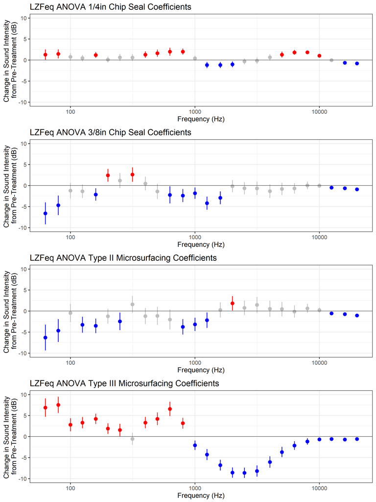

# MANOVA Analysis with LZFMax

```
##                  Df  Pillai approx F num Df den Df    Pr(>F)
## treatment         4 2.79438  13.4610    104    604 < 2.2e-16 ***
## pavetemp          1 0.27902   2.2029     26    148  0.001712 **
## speed             1 0.68111  12.1581     26    148 < 2.2e-16 ***
## pavetemp:speed    1 0.23859   1.7837     26    148  0.017130 *
## treatment:speed   4 1.02627   2.0043    104    604 2.307e-07 ***
## Residuals       173
## ---
## Signif. codes:  0 '***' 0.001 '**' 0.01 '*' 0.05 '.' 0.1 ' ' 1
```

## Post-hoc ANOVAs by LZFMax Frequency

Plotting ANOVA coefficients of change in sound intensity from pretreatment for LZFMax

Predictors: Treatment type, pavement temperature, and speed. Treatment x speed and pavement temperature x speed are included as predictors.

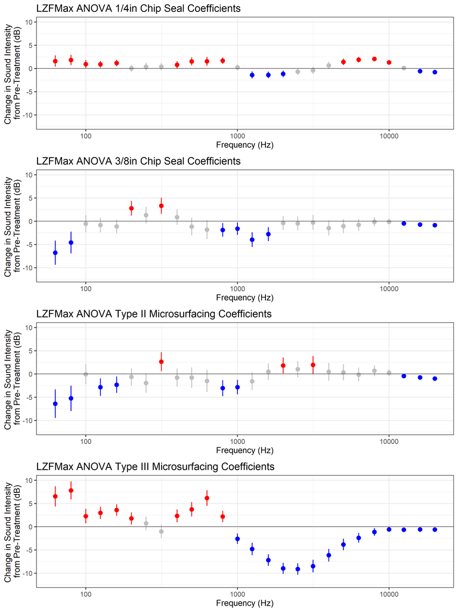